# jeopardy-locks

```python
import pandas as pd
import matplotlib.pyplot as plt
import numpy as np
import matplotlib as mpl
import seaborn as sns
import collections

# bokeh plots
from bokeh.plotting import figure, output_file, show, ColumnDataSource, reset_output
from bokeh.models import HoverTool, LinearColorMapper, Range1d, Select, CustomJS, CDSView, IndexFilter, Slider, RadioButtonGroup, Legend, CheckboxGroup, OpenURL, TapTool, Toggle, Slider, DataTable, TableColumn, Dropdown
from bokeh.io import output_notebook, curdoc
from bokeh.io import export_png, export
from bokeh.layouts import column, row, layout
from bokeh.core.enums import MarkerType
from bokeh.resources import CDN
from bokeh.embed import file_html

from IPython.display import HTML

output_notebook()
%matplotlib inline
```

## Visualizing Jeopardy! wagering in lock games

Lock games are runaway games where the leading player can't be caught in Final Jeopardy and is guaranteed to win. This occurs when the leading player has more than twice the score of the nearest competitor after Double Jeopardy.  
As an example, if Ken has \$10,000 after Double Jeopardy and the nearest player has $2,000, then Ken can wager up to \$5,999 and be guaranteed to win even if he is incorrect on Final Jeopardy. This value represents the "maximum safe wager". Do players in lock games tend to wager close to this maximum, do they play it safe and wager close to zero, or do they go somewhere in the middle? Read on to find out.

```python
def check_lock_player(r, lock_score, d):
    '''
    Find which of the 3 players has the lock score
    Add info about lock player to a dictionary
    r: row from iterrows
    lock_score: the highest score at end of DJ
    d: dict we are adding to
    '''
    for n in (1,2,3):
        if lock_score == r[f'p{n}_score_double_jeopardy']:
            d['lock_player_num'] = n
            d['final_wager'] = abs(r[f'p{n}_delta'])
            d['lock_player_name'] = r[f'p{n}_name']
            d['lock_player_correct'] = r[f'p{n}_correct']
            break
    if d['final_wager'] > d['max_wager']:
        d['overwager'] = True
        if d['final_wager'] == d['max_wager'] + 1:
            d['overwager_by_one'] = True

    lock_final_score = r[f"p{d['lock_player_num']}_final_score"]

    if lock_final_score == final_scores[2]:
        if final_scores[2] == final_scores[1]:
            d['lock_tie'] = True
        else:
            d['lock_win'] = True
    else:
        d['lock_loss'] = True
```

```python
'''
read in game-details DataFrame
find lock games and lock-tie games
get some info about them and add as new columns
'''

gdf = pd.read_csv('game-details.csv', sep=",",index_col=0)

# add new columns to df using a dictionary of {col-name: [col-items]}
new_cols = collections.defaultdict(list)

for r in gdf.iterrows():
    # use d to store items for each row that will then be appended to new_cols
    # initialize each item as either False or np.nan
    false_keys = ['is_lock','exact_lock','lock_win','lock_tie','lock_loss',
                  'overwager','lock_player_correct','overwager_by_one',]
    nan_keys = ['max_wager', 'final_wager','lock_player_num','lock_player_name']
    d = {}
    for k in false_keys:
        d[k] = False
    for k in nan_keys:
        d[k] = np.nan

    # get the sorted scores, last score will be the top score
    scores = sorted([r[1]['p1_score_double_jeopardy'], r[1]['p2_score_double_jeopardy'], r[1]['p3_score_double_jeopardy']])
    final_scores = sorted([r[1]['p1_final_score'], r[1]['p2_final_score'], r[1]['p3_final_score']])

    # check for a lock score
    if scores[2] > 2*scores[1]:
        d['max_wager'] = scores[2] - 2 * max([0,scores[1]]) - 1
        d['is_lock'] = True
        check_lock_player(r[1], scores[2], d)

    # same thing for lock-tie game
    elif scores[2] == 2*scores[1]:
        d['exact_lock'] = True
        d['max_wager'] = 0
        check_lock_player(r[1], scores[2], d)

    # append the items from d to new_cols
    for k,v in d.items():
        new_cols[k].append(v)

# add each col from new_cols to DataFrame
for k, v in new_cols.items():
    gdf[k] = v
```

```python
# variables used for plotting
right_color = "#7f7fff"
wrong_color = "#ff7f7f"

marker_type_list = list(MarkerType)
try:
    marker_type_list.remove('plus') # strange issues with plus so remove it
except:
    pass
#marker_type_list
```

```python
'''
Scatter plot of wager (as % of max safe wager) vs max safe wager
'''

lockdf = gdf[gdf['is_lock']].copy()
lockdf['percent_wager'] = lockdf['final_wager']/lockdf['max_wager']*100
lockdf['max_wager'] = lockdf.max_wager.astype(int)
lockdf['final_wager'] = lockdf.final_wager.astype(int)
lockdf['lock_outcome'] = lockdf['lock_player_correct'].replace({True:'Correct',False:'Incorrect'})

# backup columns
lockdf['density_colors'] = 'black'
lockdf['density_alphas'] = 0
lockdf['outcome_colors'] = wrong_color
lockdf.loc[lockdf['lock_player_correct'],'outcome_colors'] = right_color
lockdf['outcome_alphas'] = .5

# in-play columns
lockdf['markers'] = "circle"
lockdf['marker_sizes'] = 8
lockdf['fill_alphas'] = 0.5
lockdf['colors'] = wrong_color
lockdf.loc[lockdf['lock_player_correct'],'colors'] = right_color

# info displayed when hover over point
hover = HoverTool(names=['hover'],tooltips=[
    ('Season','@season'),('Game #','@game_number'),
    ('Player','@lock_player_name'),('Max wager','@max_wager'),
    ('Wager','@final_wager'),('Outcome','@lock_outcome')])

# get players who had more than X lock games
lock_threshold = 5
v = lockdf.lock_player_name.value_counts()
gtdf = lockdf[lockdf.lock_player_name.isin(v.index[v.gt(lock_threshold)])]
lock_players = sorted(gtdf.lock_player_name.unique())
lock_num_to_name = {i:j for i,j in enumerate(lock_players)}

src = ColumnDataSource(data=lockdf)

# widgets
color_toggle = Toggle(label="toggle coloring by correct/incorrect answer",button_type="default",active=False)
size_slider = Slider(title='Size',start=4,end=20,value=8,step=1)
marker_dropdown =Select(value='circle',options = marker_type_list)
fltr = IndexFilter(indices=list(range(lockdf.shape[0])))
player = RadioButtonGroup(labels=['All'] + lock_players, active=0)

# callback to handle everything except toggling colors
callback = CustomJS(args=dict(src=src, fltr=fltr, player=player, d=lock_num_to_name,
                              size_slider = size_slider, marker_dropdown=marker_dropdown), code='''

    const indices = [];

    const new_data = Object.assign({}, src.data)

    for (var i = 0; i < src.get_length(); i++) {
        new_data.marker_sizes[i] = size_slider.value
        new_data.markers[i] = marker_dropdown.value

        if ((player.active == 0) || (src.data['lock_player_name'][i] == d[player.active-1])) {
            indices.push(i)
        }
    }
    src.data = new_data
    fltr.indices = indices;
    src.change.emit();
''')

# callback to handle toggling colors
callback2 = CustomJS(args=dict(src=src, outcome=color_toggle), code='''

    const new_data = Object.assign({}, src.data)

    if (!outcome.active) {
        new_data.colors = src.data["outcome_colors"]
        new_data.fill_alphas = src.data['outcome_alphas']
    } else {
        new_data.colors = src.data["density_colors"]
        new_data.fill_alphas = src.data['density_alphas']
    }

    src.data = new_data
    fltr.indices = indices;
    src.change.emit();
''')

# formatting bokeh plot
p = figure(plot_width=1000, plot_height=500)
p.xaxis.axis_label = "maximum safe wager"
p.yaxis.axis_label = "wager as % of maximum safe wager"
ylim_buffer = 2
p.y_range=Range1d(-ylim_buffer, 100+ylim_buffer)
p.x_range=Range1d(0,60000)
p.xgrid.grid_line_color = None
p.ygrid.grid_line_color = None

view = CDSView(source=src, filters=[fltr])
r = p.scatter('max_wager', 'percent_wager', name='hover',size="marker_sizes",
              source=src, color='colors', fill_alpha='fill_alphas', marker="markers", view=view,)

# add trendlines
xline = np.linspace(500,90000,10000)
y1line = (xline-100)/xline*100 # wagering $100 less than max safe wager
l = p.line(xline, y1line, alpha=0.5, line_dash='dotted')
p.add_tools(HoverTool(renderers=[l], tooltips=[("$100 less than max","")]))

# lines for wagering common whole numbers 1k, 2k, 3k, 5k, 10k, 15k
for val in (1, 2, 3, 5, 10, 15):
    l = p.line(xline, np.full(xline.shape, val*1000) / xline * 100,
               alpha=.5, line_dash='dotted')
    p.add_tools(HoverTool(renderers=[l], tooltips=[(f"${val},000 wager","")]))

# on event callbacks
player.js_on_change('active', callback)
color_toggle.js_on_change('active',callback2)
size_slider.js_on_change('value',callback)
marker_dropdown.js_on_change("value", callback)

# link to jarchive when click on points
url = 'https://www.j-archive.com/showgame.php?game_id=@game_id'
p.add_tools(TapTool(renderers=[r], behavior='select', callback=OpenURL(url = url)))
p.add_tools(hover)
p.xaxis.axis_label_text_font_size = "16pt"
p.yaxis.axis_label_text_font_size = "16pt"
r.nonselection_glyph = None # to prevent fading out non-clicked on points
show(layout([[player], [size_slider,color_toggle, marker_dropdown], [p]]))
```

[interactive chart not shown]

#### Figure 1) Wagering in lock games

Wagers near the maximum safe wager appear at the top, while wagers close to 0 appear at the bottom.  
Blue/red colors indicate correct/incorrect response. Trend lines show common wager amounts (hover to show). Click on a point to link to J! Archive page.

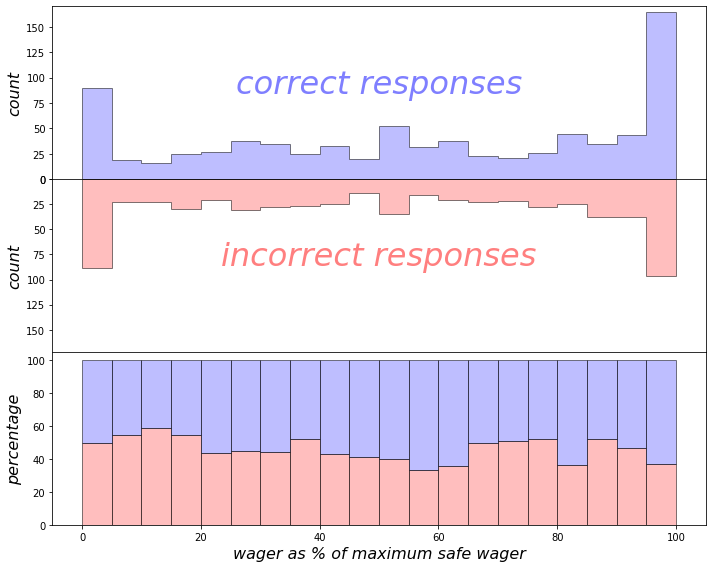

```python
'''
Generate a histogram for wagers as a % of max safe wager
Split into whether the lock player was correct/incorrect
'''
fontsize = 16

lockdf = gdf[gdf['is_lock']].copy()
lockdf['percent_wager'] = lockdf['final_wager']/lockdf['max_wager']*100
# don't include over wagers
lockdf = lockdf[lockdf['percent_wager']<=100]

right_percents = lockdf[lockdf['lock_player_correct']]['percent_wager'].values
wrong_percents = lockdf[~lockdf['lock_player_correct']]['percent_wager'].values

fig, axes = plt.subplots(nrows=3, ncols=1, sharex=True, figsize=(10,8))
r = axes[0].hist(right_percents, 20, histtype="stepfilled", color=right_color, alpha=.5, edgecolor='black')
w = axes[1].hist(wrong_percents, 20, histtype="stepfilled", color=wrong_color, alpha=.5, edgecolor='black')

# formatting
axes[1].set_ylim(axes[0].get_ylim())
axes[1].invert_yaxis()
#axes[1].set_xlabel("wager as % of maximum safe wager", style="italic",size=fontsize)
axes[0].set_ylabel('count',style="italic",size=fontsize)
axes[1].set_ylabel('count',style="italic",size=fontsize)
axes[0].set_ylim([0,170])
axes[0].text(0.5, 0.5, 'correct responses', style='italic', size=fontsize*2,
             color=right_color, transform=axes[0].transAxes, horizontalalignment='center')
axes[1].text(0.5, 0.5, 'incorrect responses', style='italic', size=fontsize*2,
             color=wrong_color, transform=axes[1].transAxes, horizontalalignment='center')

# Genereate similar histogram but use percentages instead of counts
rpercent = r[0] / (r[0]+w[0]) * 100
wpercent = w[0] / (r[0]+w[0]) * 100
#fig, ax = plt.subplots(figsize=(10,4))
width=5
axes[2].bar(r[1][:-1]+width/2, wpercent, width, color=wrong_color, alpha=0.5,edgecolor='black')
axes[2].bar(r[1][:-1]+width/2, rpercent, width, bottom=wpercent, color=right_color, alpha=0.5, edgecolor='black')
axes[2].set_xlabel("wager as % of maximum safe wager", style="italic",size=fontsize)
axes[2].set_ylabel('percentage',style="italic",size=fontsize)
fig.tight_layout()
plt.subplots_adjust(hspace=0)
```

#### Figure 2) Histograms of wagers

Contestants in lock games wager close to the maximum safe wager amount 18% of the time, and wager close to zero 12% of the time. Contestants who wagered big were more likely to be correct compared to those who wagered small (63% vs 51%).

```python
'''
Scatterplot looking at over wagers
'''
lockdf = gdf[gdf['is_lock']].copy()
overdf = lockdf[lockdf['overwager']]
lockdf = lockdf[~lockdf['overwager']] # use this for "background" points in plot

# issue where hover couldn't display apostrophe
# couldn't figure out how to fix it, so just replace apostrophe's
overdf['lock_player_name'] = overdf['lock_player_name'].str.replace("'","")
overdf['markers'] = 'square_x'
overdf.loc[overdf['lock_player_correct'],'markers'] = 'square'
overdf['lock_outcome'] = overdf['lock_player_correct'].replace({True:'Correct',False:'Incorrect'})

# overdf1 = over wagered by $1
# overdf2 = over wagered by > $1
overdf1 = overdf[overdf['overwager_by_one']].copy()
overdf2 = overdf[~overdf['overwager_by_one']].copy()
overdf2['colors'] = wrong_color
overdf1['colors'] = 'lightpink'
lockdf['colors'] = right_color

p = figure(plot_width=800, plot_height=400,)

# formatting
ylim_buffer = 2
p.xaxis.axis_label = "maximum safe wager"
p.yaxis.axis_label = "wager"
lim_range = (-200, 12005)
p.y_range=Range1d(-ylim_buffer, 100+ylim_buffer)
p.x_range = Range1d(*(lim_range))
p.y_range = Range1d(*(lim_range))

# use names=['needshover'] to only apply hover to the r1, r2 renderers
hover = HoverTool(names=['needshover'],tooltips=[
    ('Season','@season'),('Game #','@game_number'),
    ('Player',"@lock_player_name"),('Max wager','@max_wager'),
    ('Wager','@final_wager'),('Outcome','@lock_outcome'),])

url = 'https://www.j-archive.com/showgame.php?game_id=@game_id'

source_under = ColumnDataSource(data=lockdf)
source_over1 = ColumnDataSource(data=overdf1)
source_over2 = ColumnDataSource(data=overdf2)
r1 = p.scatter('max_wager', 'final_wager', source=source_under,size=10, color='colors',
               alpha=1, legend_label="safe wagers")
r2 = p.scatter('max_wager', 'final_wager', source=source_over1, name='needshover',size=14,
               marker="markers", color='colors',line_color='black',legend_label='over wagers by $1')
r3 = p.scatter('max_wager', 'final_wager', source=source_over2, name='needshover',size=14,
               marker="markers", color='colors',line_color='black',legend_label='over wagers by > $1')
p.add_tools(hover)

p.xaxis.axis_label_text_font_size = "16pt"
p.yaxis.axis_label_text_font_size = "16pt"
p.legend.location = 'top_left'
p.legend.label_text_font_size="12pt"

p.add_tools(TapTool(renderers=[r2,r3], behavior='select',callback=OpenURL(url = url)))
r1.nonselection_glyph = None
r2.nonselection_glyph = None
r3.nonselection_glyph = None
show(p)
```

[interactive chart not shown]

#### Figure 3) Lock games with over-wagers

Over-wagers are when a contestant has a lock game but wagers more than the maximum safe wager. Over-wagers by \$1 are most common (pink color) - in this case if the leading player is wrong on Final Jeopardy there is the possibility of a tie. Over-wagers by more than \$1 (red color) leave open the possibility of losing.  
Squares with an "X" mean the leading player was incorrect on Final Jeopardy. Click on a square to link to the J! Archive game.

```python
def sankey():
    '''
    Generate input for sankey plot
    '''
    soft_lock_name = 'lock-tie'
    lock_name = 'lock'

    alllock = gdf[(gdf['is_lock']==True) | (gdf['exact_lock']==True)]
    reallock= gdf[gdf['is_lock']]
    softlock = gdf[gdf['exact_lock']]
    #print('all lock',alllock.shape[0])
    #print(f'all lock [{reallock.shape[0]}] hard lock')
    #print(f'all lock [{softlock.shape[0]}] soft lock')

    #eldf.to_csv('exact_lock.csv',sep=',')
    slbidtowin = softlock[softlock['final_wager']>0]
    slbidtotie = softlock[softlock['final_wager']==0]
    print(f'{soft_lock_name} [{slbidtowin.shape[0]}] {soft_lock_name} wager to win')
    print(f'{soft_lock_name} [{slbidtotie.shape[0]}] {soft_lock_name} wager to tie')

    rlbidtotie = reallock[reallock['overwager_by_one']]
    rloverbid = reallock[(reallock['overwager']) & (~reallock['overwager_by_one'])]
    rlsafebid = reallock[(~reallock['overwager_by_one']) & (~reallock['overwager'])]
    print(f'{lock_name} [{rlbidtotie.shape[0]}] {lock_name} over wager by one')
    print(f'{lock_name} [{rloverbid.shape[0]}] {lock_name} over wager by more')
    #print(f'{lock_name} [{rlsafebid.shape[0]}] hard lock safe wager')

    slbidtowin_win = slbidtowin[slbidtowin['lock_win']]
    slbidtowin_tie = slbidtowin[slbidtowin['lock_tie']]
    slbidtowin_loss = slbidtowin[slbidtowin['lock_loss']]
    print(f'{soft_lock_name} wager to win [{slbidtowin_win.shape[0]}] win')
    print(f'{soft_lock_name} wager to win [{slbidtowin_tie.shape[0]}] tie')
    print(f'{soft_lock_name} wager to win [{slbidtowin_loss.shape[0]}] loss')

    slbidtotie_win = slbidtotie[slbidtotie['lock_win']]
    slbidtotie_tie = slbidtotie[slbidtotie['lock_tie']]
    slbidtotie_loss = slbidtotie[slbidtotie['lock_loss']]
    print(f'{soft_lock_name} wager to tie [{slbidtotie_win.shape[0]}] win')
    print(f'{soft_lock_name} wager to tie [{slbidtotie_tie.shape[0]}] tie')
    print(f'{soft_lock_name} wager to tie [{slbidtotie_loss.shape[0]}] loss')

    rlbidtotie_win = rlbidtotie[rlbidtotie['lock_win']]
    rlbidtotie_tie = rlbidtotie[rlbidtotie['lock_tie']]
    rlbidtotie_loss = rlbidtotie[rlbidtotie['lock_loss']]
    print(f'{lock_name} over wager by one [{rlbidtotie_win.shape[0]}] win')
    print(f'{lock_name} over wager by one [{rlbidtotie_tie.shape[0]}] tie')
    print(f'{lock_name} over wager by one [{rlbidtotie_loss.shape[0]}] loss')

    rloverbid_win = rloverbid[rloverbid['lock_win']]
    rloverbid_tie = rloverbid[rloverbid['lock_tie']]
    rloverbid_loss = rloverbid[rloverbid['lock_loss']]
    print(f'{lock_name} over wager by more [{rloverbid_win.shape[0]}] win')
    print(f'{lock_name} over wager by more [{rloverbid_tie.shape[0]}] tie')
    print(f'{lock_name} over wager by more [{rloverbid_loss.shape[0]}] loss')

    rlsafebid_win = rlsafebid[rlsafebid['lock_win']]
    rlsafebid_tie = rlsafebid[rlsafebid['lock_tie']]
    rlsafebid_loss = rlsafebid[rlsafebid['lock_loss']]
    #print(f'{lock_name} safe wager [{rlsafebid_win.shape[0]}] win')
    #print(f'{lock_name} safe wager [{rlsafebid_tie.shape[0]}] tie')
    #print(f'{lock_name} safe wager [{rlsafebid_loss.shape[0]}] loss')

    print(":loss #d82e3f")
    print(":win #28cc2d")
    print(":tie #FFC107")
    print(f":{soft_lock_name} wager to win #63c5da")
    print(f":{soft_lock_name} wager to tie #0492c2")
    print(f":{lock_name} over wager by one #1338be")
    print(f":{lock_name} over wager by more #0a1172")
```

[figure not shown]

#### Figure 4) Outcomes in different lock game scenarios

Lock-tie games occur when the leading player has exactly twice the score of the nearest competitor. If they wager \$0 it leaves open the possibility of a tie. If they wager > \$0 it leaves open the possibility of a loss. The above figure shows how often the 41 lock-tie games resulted in a win, tie, or loss for the leading player.  
It also shows the outcomes of the 47 lock games where the leading player over-wagered. Plot generated with [sankeymatic](https://sankeymatic.com)

```python
'''
DataTable for lock games with an over wager
'''

lockdf = gdf[gdf['is_lock']].copy()
lockdf['lock_outcome'] = lockdf['lock_player_correct'].replace({True:'Correct',False:'Incorrect'})
overdf = lockdf[lockdf['overwager']].copy()
second_place_outcomes = []
final_outcomes = []

for t in overdf.iterrows():
    r = t[1]

    # see if second-best score got final jeopardy correct
    scores = [r['p1_score_double_jeopardy'], r['p2_score_double_jeopardy'], r['p3_score_double_jeopardy']]
    scores = sorted(scores)
    second_place_right = 'Incorrect'
    for n in (1,2,3):
        if r[f'p{n}_score_double_jeopardy'] == scores[1]:
            if r[f'p{n}_correct']:
                second_place_right = 'Correct'
    second_place_outcomes.append(second_place_right)

    # see what final outcome was (win / loss / tie)
    final_scores = [r['p1_final_score'], r['p2_final_score'], r['p3_final_score']]
    final_scores = sorted(final_scores)
    lpn = r["lock_player_num"]
    if r[f"p{int(lpn)}_final_score"] == final_scores[2]:
        if final_scores[1] == final_scores[2]:
            final_outcomes.append("Tie")
        else:
            final_outcomes.append('Win')
    else:
        final_outcomes.append("Loss")

overdf['second_place_outcome'] = second_place_outcomes
overdf['final_outcome'] = final_outcomes

# Bokeh DataTable
source = ColumnDataSource(overdf)
columns = [TableColumn(field="game_number", title="Game #",),
           TableColumn(field="lock_player_name", title="Player"),
           TableColumn(field="max_wager", title="Max safe wager"),
           TableColumn(field="final_wager", title="Wager"),
           TableColumn(field="lock_outcome", title="Lock answer"),
           TableColumn(field="second_place_outcome", title="2nd place answer"),
           TableColumn(field="final_outcome",title="Game result")]
data_table = DataTable(source=source, columns=columns, width=800, height=500)
show(data_table)
```

[interactive chart not shown]

#### Figure 5) Lock game over-wagers

Data from the 47 lock games where the leading player over-wagered.

```python
'''
DataTable for lock-tie games
'''

lockdf = gdf[gdf['exact_lock']].copy()
lockdf['lock_outcome'] = lockdf['lock_player_correct'].replace({True:'Correct',False:'Incorrect'})
overdf = lockdf.copy()
second_place_outcomes = []
final_outcomes = []

for t in overdf.iterrows():
    r = t[1]

    # see if second-best score got final jeopardy correct
    scores = [r['p1_score_double_jeopardy'], r['p2_score_double_jeopardy'], r['p3_score_double_jeopardy']]
    scores = sorted(scores)
    second_place_right = 'Incorrect'
    for n in (1,2,3):
        if r[f'p{n}_score_double_jeopardy'] == scores[1]:
            if r[f'p{n}_correct']:
                second_place_right = 'Correct'
    second_place_outcomes.append(second_place_right)

    # see what final outcome was (win / loss / tie)
    final_scores = [r['p1_final_score'], r['p2_final_score'], r['p3_final_score']]
    final_scores = sorted(final_scores)
    lpn = r["lock_player_num"]
    if r[f"p{int(lpn)}_final_score"] == final_scores[2]:
        if final_scores[1] == final_scores[2]:
            final_outcomes.append("Tie")
        else:
            final_outcomes.append('Win')
    else:
        final_outcomes.append("Loss")

overdf['second_place_outcome'] = second_place_outcomes
overdf['final_outcome'] = final_outcomes

# Bokeh DataTable
source = ColumnDataSource(overdf)
columns = [TableColumn(field="game_number", title="Game #",),
           TableColumn(field="lock_player_name", title="Player"),
           TableColumn(field="final_wager", title="Wager"),
           TableColumn(field="lock_outcome", title="Lock answer"),
           TableColumn(field="second_place_outcome", title="2nd place answer"),
           TableColumn(field="final_outcome",title="Game result")]
data_table = DataTable(source=source, columns=columns, width=800, height=500)
show(data_table)
```

[interactive chart not shown]

#### Figure 6) Lock-tie games

Data from 41 lock-tie games.

Data from [J! Archive](https://j-archive.com/)

```python
HTML('''<script>
code_show=true;
function code_toggle() {
 if (code_show){
 $('div.input').hide();
 } else {
 $('div.input').show();
 }
 code_show = !code_show
}
$( document ).ready(code_toggle);
</script>
The raw code for this IPython notebook is by default hidden for easier reading.
To toggle on/off the raw code, click <a href="javascript:code_toggle()">here</a>.''')
```

The raw code for this IPython notebook is by default hidden for easier reading. To toggle on/off the raw code, click here.